# Poisson Regression

#### Poisson Regression Model:

We model the count data directly (rather than the rate which doesn’t follow a Poisson distribution), using the population (log transformed) as an offset variable in order to transform back to rates.

```r
library(Epi)

model1 <- glm(infarcts ~ offset(log(stdpop)) + smokban + time, family=poisson, data)
summary(model1)
```

```
##
## Call:
## glm(formula = infarcts ~ offset(log(stdpop)) + smokban + time,
##     family = poisson, data = data)
##
## Deviance Residuals:
##     Min       1Q   Median       3Q      Max
## -3.4336  -1.4432  -0.4431   1.2735   5.0701
##
## Coefficients:
##               Estimate Std. Error  z value Pr(>|z|)
## (Intercept) -6.2431509  0.0111894 -557.955  < 2e-16 ***
## smokban     -0.1116284  0.0172248   -6.481 9.13e-11 ***
## time         0.0049450  0.0004992    9.905  < 2e-16 ***
## ---
## Signif. codes:  0 '***' 0.001 '**' 0.01 '*' 0.05 '.' 0.1 ' ' 1
##
## (Dispersion parameter for poisson family taken to be 1)
##
##     Null deviance: 308.52  on 58  degrees of freedom
## Residual deviance: 197.31  on 56  degrees of freedom
## AIC: 708.03
##
## Number of Fisher Scoring iterations: 3
```

```r
round(ci.lin(model1,Exp=T),3)
```

```
##             Estimate StdErr        z P exp(Est.)  2.5% 97.5%
## (Intercept)   -6.243  0.011 -557.955 0     0.002 0.002 0.002
## smokban       -0.112  0.017   -6.481 0     0.894 0.865 0.925
## time           0.005  0.000    9.905 0     1.005 1.004 1.006
```

The predictions with this model are as follows:

```r
# Predictions:

datanew <- data.frame(stdpop = mean(data$stdpop),
                      smokban = rep(c(0, 1), c(360, 240)),
                      time = 1:600/10,
                      month = rep(1:120/10, 5))

head(datanew)
```

```
##     stdpop smokban time month
## 1 383464.4       0  0.1   0.1
## 2 383464.4       0  0.2   0.2
## 3 383464.4       0  0.3   0.3
## 4 383464.4       0  0.4   0.4
## 5 383464.4       0  0.5   0.5
## 6 383464.4       0  0.6   0.6
```

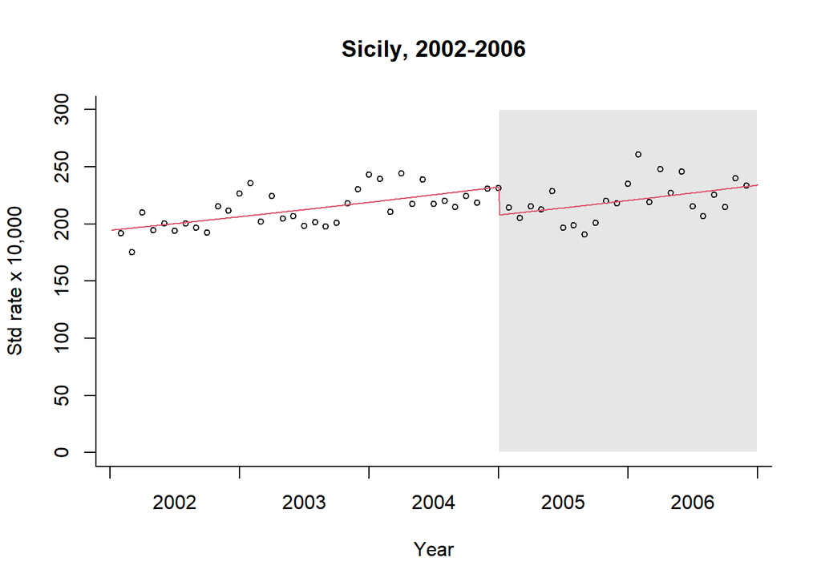

```r
pred1 <- predict(model1, type="response", datanew) / mean(data$stdpop) * 10^5

plot(data$infarct.rate, type="n", ylim=c(0,300), xlab="Year", ylab="Std rate x 10,000", bty="l", xaxt="n")
rect(36, 0, 60, 300, col=grey(0.9), border=F)
points(data$infarct.rate,cex=0.7)
axis(1, at=0:5*12, labels=F)
axis(1, at=0:4*12+6, tick=F, labels=2002:2006)
lines((1:600/10), pred1, col=2)
title("Sicily, 2002-2006")
```

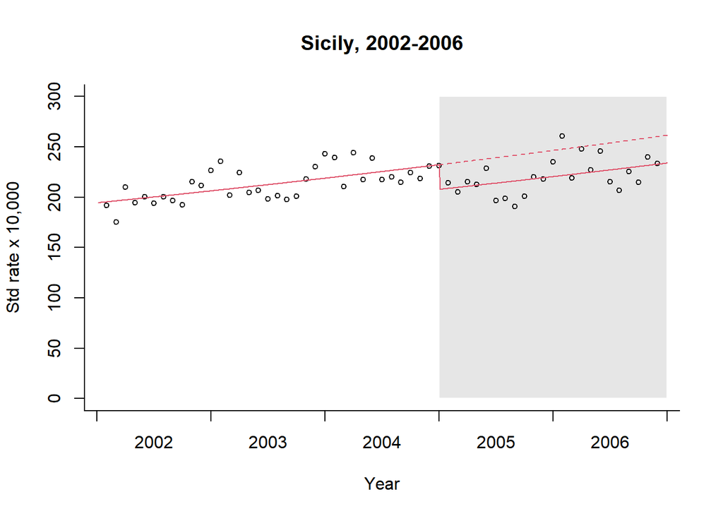

```r
# To plot the counterfactual scenario we create a data frame as if smokban (the intervention) had never been implemented.

datanew <- data.frame(stdpop=mean(data$stdpop),smokban=0,time=1:600/10,
  month=rep(1:120/10,5))

pred1b <- predict(model1, datanew, type="response") / mean(data$stdpop) * 10^5

plot(data$infarct.rate, type="n", ylim=c(0,300), xlab="Year", ylab="Std rate x 10,000", bty="l", xaxt="n")
rect(36, 0, 60, 300, col=grey(0.9), border=F)
points(data$infarct.rate,cex=0.7)
axis(1, at=0:5*12, labels=F)
axis(1, at=0:4*12+6, tick=F, labels=2002:2006)
lines((1:600/10), pred1, col=2)
lines(datanew$time, pred1b, col=2, lty=2)
title("Sicily, 2002-2006")
```

In the model above we have not allowed for overdispersion - in order to do this we can use a quasipoisson model, which allows the variance to be proportional rather than equal to the mean.

```r
model2 <- glm(infarcts ~ offset(log(stdpop)) + smokban + time,
              family=quasipoisson, data)
summary(model2)
```

```
##
## Call:
## glm(formula = infarcts ~ offset(log(stdpop)) + smokban + time,
##     family = quasipoisson, data = data)
##
## Deviance Residuals:
##     Min       1Q   Median       3Q      Max
## -3.4336  -1.4432  -0.4431   1.2735   5.0701
##
## Coefficients:
##               Estimate Std. Error  t value Pr(>|t|)
## (Intercept) -6.2431509  0.0211096 -295.749  < 2e-16 ***
## smokban     -0.1116284  0.0324959   -3.435  0.00112 **
## time         0.0049450  0.0009418    5.250 2.43e-06 ***
## ---
## Signif. codes:  0 '***' 0.001 '**' 0.01 '*' 0.05 '.' 0.1 ' ' 1
##
## (Dispersion parameter for quasipoisson family taken to be 3.559195)
##
##     Null deviance: 308.52  on 58  degrees of freedom
## Residual deviance: 197.31  on 56  degrees of freedom
## AIC: NA
##
## Number of Fisher Scoring iterations: 3
```

A second assumption of standard regression models is that observations are independent. This assumption is often violated in time series data because consecutive observations tend to be more similar to one another than those that are further apart, a phenomenon known as autocorrelation. Fortunately, in many epidemiological data, autocorrelation is largely explained by other variables, in particular seasonality (discussed above); therefore, after controlling for these factors, residual autocorrelation is rarely a problem. Nevertheless, autocorrelation should always be assessed by examining the plot of residuals and the partial autocorrelation function and, where data are normally distributed, conducting tests such as the Breusch-Godfrey test.22,25 Where residual autocorrelation remains, this should be adjusted for using methods such as Prais regression or autoregressive integrated moving average (ARIMA), described in more detail elsewhere. There is very little evidence of autocorrelation in the worked example and even less after adjustment for seasonality.

### Checking for correlation, autocorrelation and seasonality in the residuals:

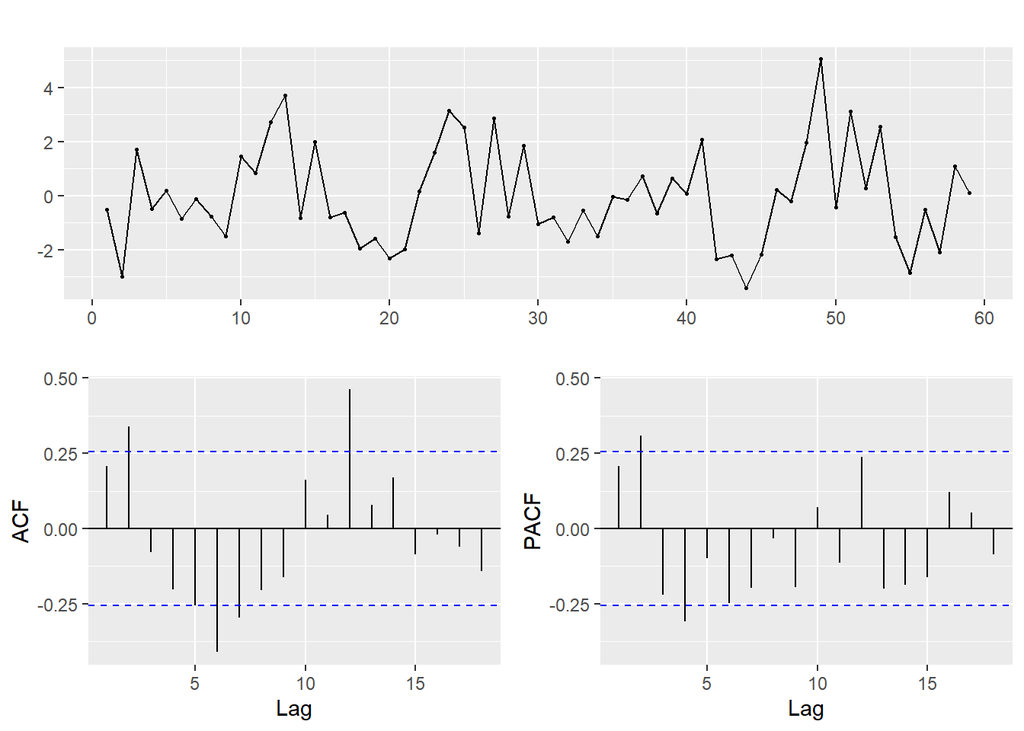

```r
# Checking autocorrelation and partial autocorrelation in the model (using residuals):
library(ggplot2)
library(cowplot)
library(fpp2)

res2 <- residuals(model2, type="deviance")

ggtsdisplay(res2)
```

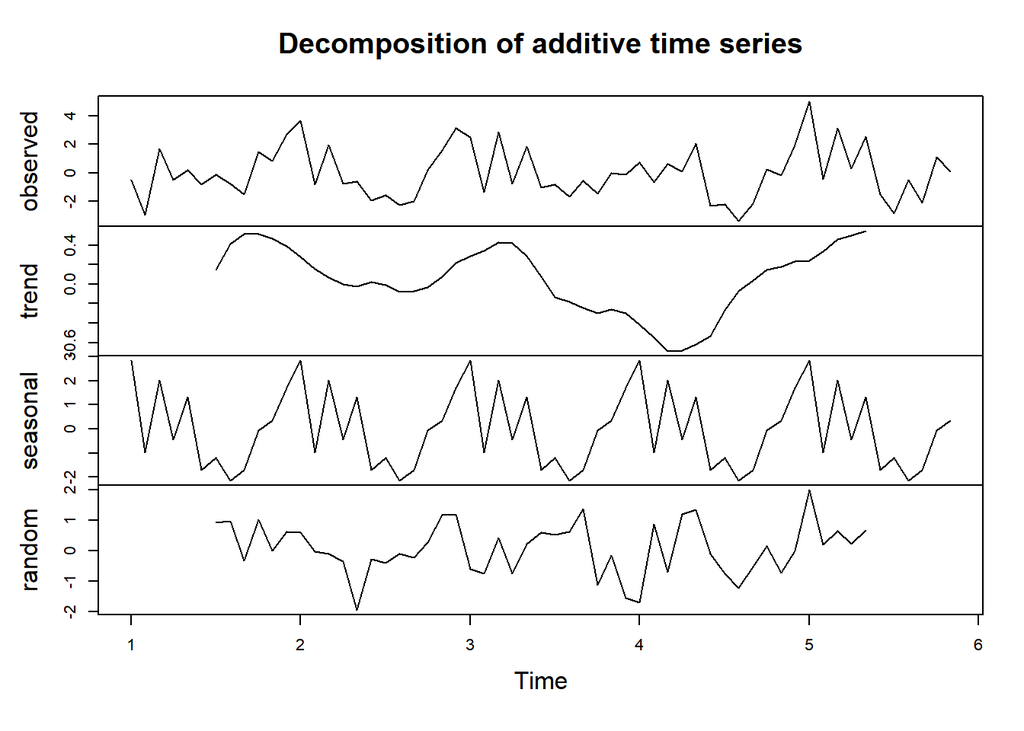

```r
pattern <- decompose(ts(res2, frequency=12))
plot(pattern)
```

```r
!is.null(tbats(ts(res2, frequency=12))$seasonal)
```

```
## [1] TRUE
```

Clearly there is residual seasonality. There are various ways of adjusting for seasonality - here we use harmonic terms specifying the number of sin and cosine pairs to include (in this case 3) and the length of the period (12 months):

```r
library(tsModel)

model3 <- glm(infarcts ~ offset(log(stdpop)) + smokban + time + harmonic(month,3,12),
              family=quasipoisson, data)
summary(model3)
```

```
##
## Call:
## glm(formula = infarcts ~ offset(log(stdpop)) + smokban + time +
##     harmonic(month, 3, 12), family = quasipoisson, data = data)
##
## Deviance Residuals:
##    Min      1Q  Median      3Q     Max
## -3.189  -1.055  -0.107   1.037   3.468
##
## Coefficients:
##                           Estimate Std. Error  t value Pr(>|t|)
## (Intercept)             -6.2521824  0.0176090 -355.056  < 2e-16 ***
## smokban                 -0.1210185  0.0271207   -4.462 4.62e-05 ***
## time                     0.0053751  0.0007985    6.731 1.58e-08 ***
## harmonic(month, 3, 12)1  0.0368454  0.0100163    3.679 0.000574 ***
## harmonic(month, 3, 12)2 -0.0182348  0.0096298   -1.894 0.064075 .
## harmonic(month, 3, 12)3  0.0062659  0.0095570    0.656 0.515061
## harmonic(month, 3, 12)4  0.0386223  0.0096767    3.991 0.000215 ***
## harmonic(month, 3, 12)5  0.0149246  0.0097112    1.537 0.130636
## harmonic(month, 3, 12)6  0.0127700  0.0097201    1.314 0.194921
## ---
## Signif. codes:  0 '***' 0.001 '**' 0.01 '*' 0.05 '.' 0.1 ' ' 1
##
## (Dispersion parameter for quasipoisson family taken to be 2.256077)
##
##     Null deviance: 308.52  on 58  degrees of freedom
## Residual deviance: 112.39  on 50  degrees of freedom
## AIC: NA
##
## Number of Fisher Scoring iterations: 3
```

```r
round(ci.lin(model3,Exp=T),3)
```

```
##                         Estimate StdErr        z     P exp(Est.)  2.5% 97.5%
## (Intercept)               -6.252  0.018 -355.056 0.000     0.002 0.002 0.002
## smokban                   -0.121  0.027   -4.462 0.000     0.886 0.840 0.934
## time                       0.005  0.001    6.731 0.000     1.005 1.004 1.007
## harmonic(month, 3, 12)1    0.037  0.010    3.679 0.000     1.038 1.017 1.058
## harmonic(month, 3, 12)2   -0.018  0.010   -1.894 0.058     0.982 0.964 1.001
## harmonic(month, 3, 12)3    0.006  0.010    0.656 0.512     1.006 0.988 1.025
## harmonic(month, 3, 12)4    0.039  0.010    3.991 0.000     1.039 1.020 1.059
## harmonic(month, 3, 12)5    0.015  0.010    1.537 0.124     1.015 0.996 1.035
## harmonic(month, 3, 12)6    0.013  0.010    1.314 0.189     1.013 0.994 1.032
```

```r
ci.lin(model3,Exp=T)["smokban",5:7]
```

```
## exp(Est.)      2.5%     97.5%
## 0.8860176 0.8401506 0.9343886
```

After adjusting for seasonality:

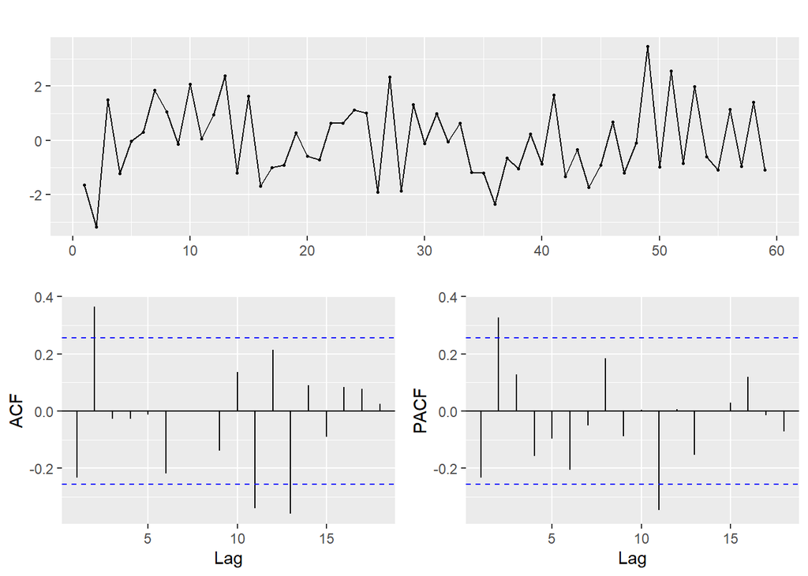

```r
# After adjusting for seasonality:

# Checking residuals:

res3 <- residuals(model3,type="deviance")

ggtsdisplay(res3)
```

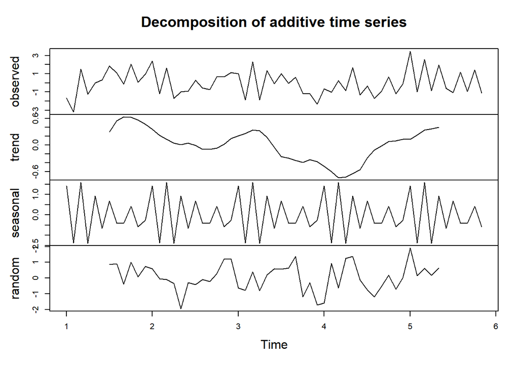

```r
pattern <- decompose(ts(res3, frequency=12))
plot(pattern)
```

```r
!is.null(tbats(ts(res3, frequency=12))$seasonal)
```

```
## [1] FALSE
```

After adjustment for seasonality through a Fourier term, with results suggesting that the association is largely unaffected: `(RR: 0.885; 95% CI 0.839-0.933; P < 0.001).`

Taking into account seasonality of the ACE rate, the ACE rate was being multiplied by about 1.07 each year, a long-term temporal trend.

```r
exp(coef(model3)["time"]*12)
```

```
##     time
## 1.066627
```

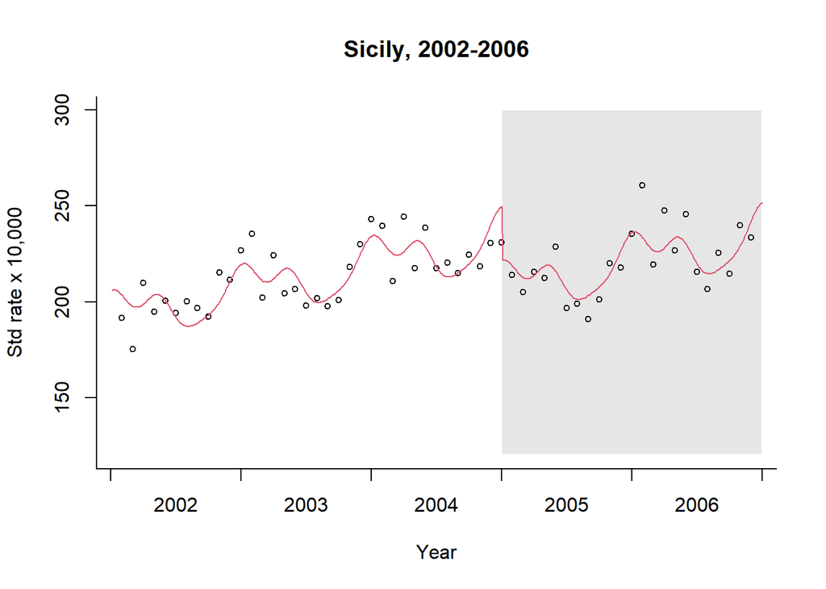

```r
# Predict and plot of the seasonally adjusted model


datanew <- data.frame(stdpop = mean(data$stdpop),
                      smokban = rep(c(0, 1), c(360, 240)),
                      time = 1:600/10,
                      month = rep(1:120/10, 5))

pred3 <- predict(model3, type="response", datanew) / mean(data$stdpop) * 10^5

plot(data$infarct.rate, type="n", ylim=c(120,300), xlab="Year", ylab="Std rate x 10,000", bty="l", xaxt="n")
rect(36, 120, 60, 300, col=grey(0.9), border=F)
points(data$infarct.rate, cex=0.7)
axis(1, at=0:5*12, labels=F)
axis(1, at=0:4*12+6, tick=F, labels=2002:2006)
lines(1:600/10, pred3, col=2)
title("Sicily, 2002-2006")
```

[Home Page](http://rinterested.github.io/statistics/index.html)

**NOTE: These are tentative notes on different topics for personal use - expect mistakes and misunderstandings.**